# sanjay_23_01_2022

```python
from sklearn.datasets import load_boston
import pandas as pd
import numpy as np
import seaborn as sns
import matplotlib.pyplot as plt
import statsmodels.api as sm
from sklearn.model_selection import train_test_split,GridSearchCV
from sklearn.linear_model import LinearRegression
from sklearn import metrics
from sklearn.metrics import mean_squared_error,roc_auc_score,roc_curve,classification_report,confusion_matrix,plot_confusion_matrix
from statsmodels.stats.outliers_influence import variance_inflation_factor
import math
plt.rc("font", size=14)
import seaborn as sns
sns.set(style="white")
sns.set(style="whitegrid", color_codes=True)
from os import system

from sklearn.discriminant_analysis import LinearDiscriminantAnalysis
```

### Problem 1:

### You are hired by one of the leading news channels CNBE who wants to analyze recent elections. This survey was conducted on 1525 voters with 9 variables. You have to build a model, to predict which party a voter will vote for on the basis of the given information, to create an exit poll that will help in predicting overall win and seats covered by a particular party.

### 1.1 Read the dataset. Do the descriptive statistics and do the null value condition check. Write an inference on it. (4 Marks)

```python
df = pd.read_excel("Election_Data.xlsx",sheet_name='Election_Dataset_Two Classes')
df.head()
```

|  | Unnamed: 0 | vote | age | economic.cond.national | economic.cond.household | Blair | Hague | Europe | political.knowledge | gender |
| --- | --- | --- | --- | --- | --- | --- | --- | --- | --- | --- |
| 0 | 1 | Labour | 43 | 3 | 3 | 4 | 1 | 2 | 2 | female |
| 1 | 2 | Labour | 36 | 4 | 4 | 4 | 4 | 5 | 2 | male |
| 2 | 3 | Labour | 35 | 4 | 4 | 5 | 2 | 3 | 2 | male |
| 3 | 4 | Labour | 24 | 4 | 2 | 2 | 1 | 4 | 0 | female |
| 4 | 5 | Labour | 41 | 2 | 2 | 1 | 1 | 6 | 2 | male |

```python
df.dtypes
```

```
Unnamed: 0                  int64
vote                       object
age                         int64
economic.cond.national      int64
economic.cond.household     int64
Blair                       int64
Hague                       int64
Europe                      int64
political.knowledge         int64
gender                     object
dtype: object
```

```python
df.shape
```

```
(1525, 10)
```

```python
df.describe(include="all")
```

|  | Unnamed: 0 | vote | age | economic.cond.national | economic.cond.household | Blair | Hague | Europe | political.knowledge | gender |
| --- | --- | --- | --- | --- | --- | --- | --- | --- | --- | --- |
| count | 1525.000000 | 1525 | 1525.000000 | 1525.000000 | 1525.000000 | 1525.000000 | 1525.000000 | 1525.000000 | 1525.000000 | 1525 |
| unique | NaN | 2 | NaN | NaN | NaN | NaN | NaN | NaN | NaN | 2 |
| top | NaN | Labour | NaN | NaN | NaN | NaN | NaN | NaN | NaN | female |
| freq | NaN | 1063 | NaN | NaN | NaN | NaN | NaN | NaN | NaN | 812 |
| mean | 763.000000 | NaN | 54.182295 | 3.245902 | 3.140328 | 3.334426 | 2.746885 | 6.728525 | 1.542295 | NaN |
| std | 440.373894 | NaN | 15.711209 | 0.880969 | 0.929951 | 1.174824 | 1.230703 | 3.297538 | 1.083315 | NaN |
| min | 1.000000 | NaN | 24.000000 | 1.000000 | 1.000000 | 1.000000 | 1.000000 | 1.000000 | 0.000000 | NaN |
| 25% | 382.000000 | NaN | 41.000000 | 3.000000 | 3.000000 | 2.000000 | 2.000000 | 4.000000 | 0.000000 | NaN |
| 50% | 763.000000 | NaN | 53.000000 | 3.000000 | 3.000000 | 4.000000 | 2.000000 | 6.000000 | 2.000000 | NaN |
| 75% | 1144.000000 | NaN | 67.000000 | 4.000000 | 4.000000 | 4.000000 | 4.000000 | 10.000000 | 2.000000 | NaN |
| max | 1525.000000 | NaN | 93.000000 | 5.000000 | 5.000000 | 5.000000 | 5.000000 | 11.000000 | 3.000000 | NaN |

```python
df.info()
```

```
<class 'pandas.core.frame.DataFrame'>
RangeIndex: 1525 entries, 0 to 1524
Data columns (total 10 columns):
Unnamed: 0                 1525 non-null int64
vote                       1525 non-null object
age                        1525 non-null int64
economic.cond.national     1525 non-null int64
economic.cond.household    1525 non-null int64
Blair                      1525 non-null int64
Hague                      1525 non-null int64
Europe                     1525 non-null int64
political.knowledge        1525 non-null int64
gender                     1525 non-null object
dtypes: int64(8), object(2)
memory usage: 119.2+ KB
```

```python
df.isnull().sum()
```

```
Unnamed: 0                 0
vote                       0
age                        0
economic.cond.national     0
economic.cond.household    0
Blair                      0
Hague                      0
Europe                     0
political.knowledge        0
gender                     0
dtype: int64
```

From this we can infer that there are no null values present in the data.

```python
dups = df.duplicated()
print('Number of duplicate rows = %d' % (dups.sum()))
```

```
Number of duplicate rows = 0
```

### 1.2 Perform Univariate and Bivariate Analysis. Do exploratory data analysis. Check for Outliers. (7 Marks)

##### Uni-Variate Analysis

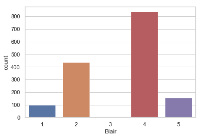

```python
sns.countplot(df["Blair"])
```

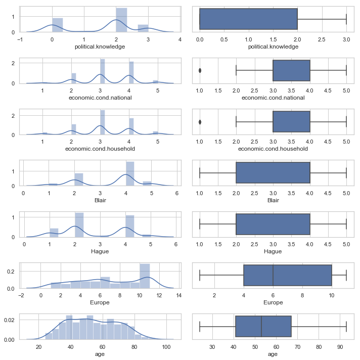

```python
fig, axes = plt.subplots(nrows=7,ncols=2)
fig.set_size_inches(10,10)
sns.distplot(df['political.knowledge'], kde=True, ax=axes[0][0])
sns.boxplot(x='political.knowledge', data=df, ax=axes[0][1])
sns.distplot(df['economic.cond.national'] , kde=True, ax=axes[1][0])
sns.boxplot(x='economic.cond.national', data=df , ax=axes[1][1])
sns.distplot(df['economic.cond.household'] , kde=True, ax=axes[2][0])
sns.boxplot(x='economic.cond.household', data=df , ax=axes[2][1])
sns.distplot(df['Blair'], kde=True, ax=axes[3][0])
sns.boxplot(x='Blair', data=df, ax=axes[3][1])
sns.distplot(df['Hague'] , kde=True, ax=axes[4][0])
sns.boxplot(x='Hague', data=df , ax=axes[4][1])
sns.distplot(df['Europe'] , kde=True, ax=axes[5][0])
sns.boxplot(x='Europe', data=df , ax=axes[5][1])
sns.distplot(df['age'] , kde=True, ax=axes[6][0])
sns.boxplot(x='age', data=df , ax=axes[6][1])
plt.tight_layout()
plt.show()
```

From the above chart (displot and boxplot), there are outliers present in the economic.cond.national and economic.cond.household data. We can infer that there is no trend or pattern that it follows a normal distribution.

##### Bi-Variate Analysis

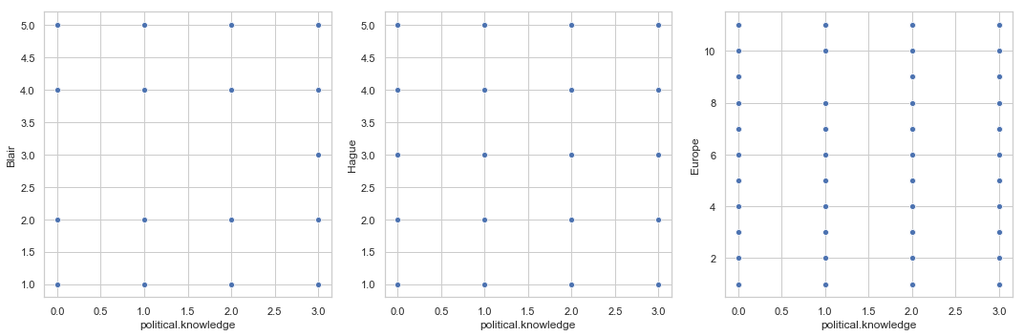

```python
fig, axes = plt.subplots(nrows=1,ncols=3)
fig.set_size_inches(15,5)
# plt.figure(figsize=(12,7))
sns.scatterplot(df['political.knowledge'], df['Blair'], ax=axes[0])
sns.scatterplot(df['political.knowledge'], df['Hague'], ax=axes[1])
sns.scatterplot(df['political.knowledge'], df['Europe'], ax=axes[2])
plt.tight_layout()
plt.show()
```

##### Multi-Variate Analysis

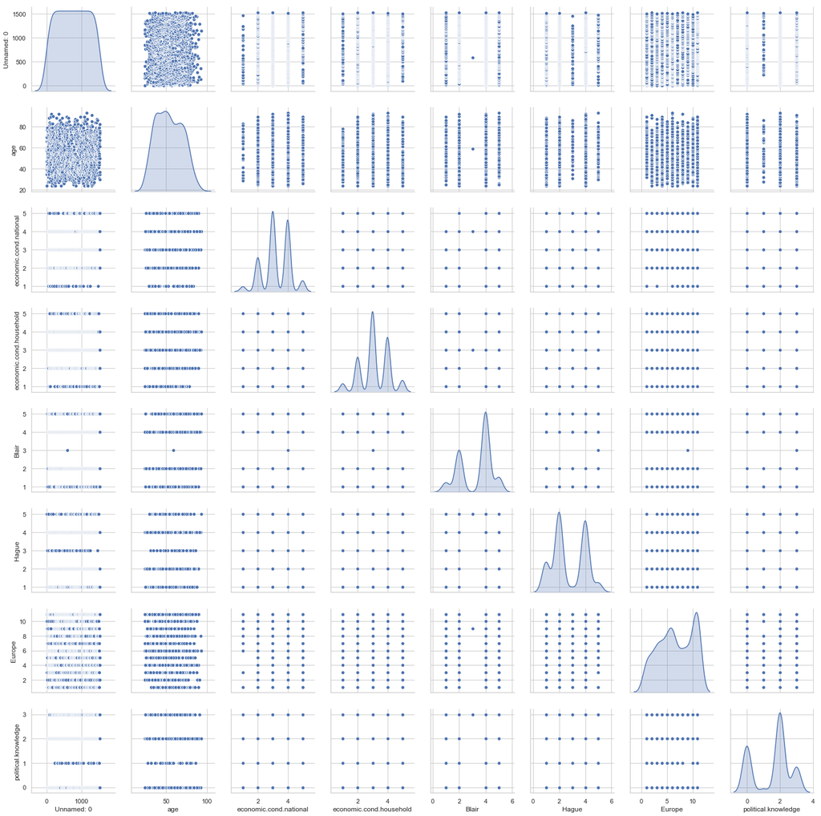

```python
sns.pairplot(df,diag_kind="kde")
```

```python
df.corr()
```

|  | Unnamed: 0 | age | economic.cond.national | economic.cond.household | Blair | Hague | Europe | political.knowledge |
| --- | --- | --- | --- | --- | --- | --- | --- | --- |
| Unnamed: 0 | 1.000000 | 0.005128 | 0.071882 | 0.035907 | 0.001602 | 0.000282 | 0.038218 | 0.002485 |
| age | 0.005128 | 1.000000 | 0.018567 | -0.041587 | 0.030218 | 0.034626 | 0.068880 | -0.048490 |
| economic.cond.national | 0.071882 | 0.018567 | 1.000000 | 0.346303 | 0.326878 | -0.199766 | -0.209429 | -0.023624 |
| economic.cond.household | 0.035907 | -0.041587 | 0.346303 | 1.000000 | 0.215273 | -0.101956 | -0.114885 | -0.037810 |
| Blair | 0.001602 | 0.030218 | 0.326878 | 0.215273 | 1.000000 | -0.243210 | -0.296162 | -0.020917 |
| Hague | 0.000282 | 0.034626 | -0.199766 | -0.101956 | -0.243210 | 1.000000 | 0.287350 | -0.030354 |
| Europe | 0.038218 | 0.068880 | -0.209429 | -0.114885 | -0.296162 | 0.287350 | 1.000000 | -0.152364 |
| political.knowledge | 0.002485 | -0.048490 | -0.023624 | -0.037810 | -0.020917 | -0.030354 | -0.152364 | 1.000000 |

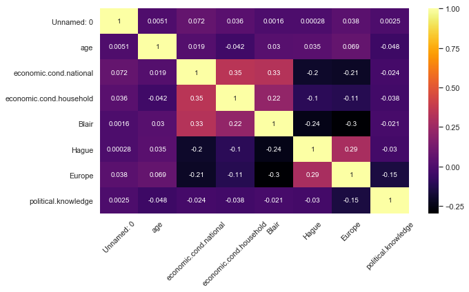

```python
plt.figure(figsize=(10,6))
sns.heatmap(df.corr(),annot=True,cmap='inferno')
plt.xticks(rotation=45)
plt.tight_layout()
plt.show()
```

```python
df_cat = df.select_dtypes(include = ['object'])
df_num = df.select_dtypes(include = ['float64','int64'])
```

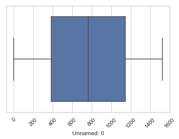

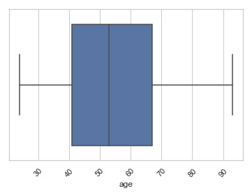

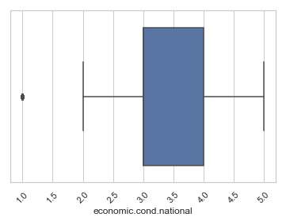

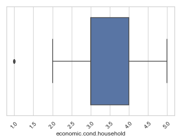

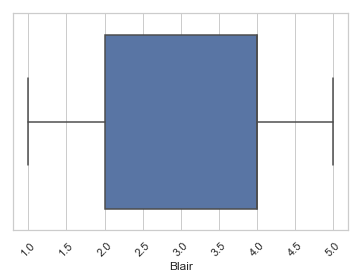

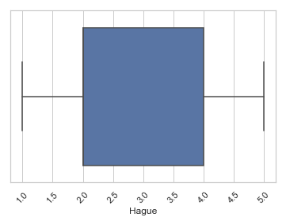

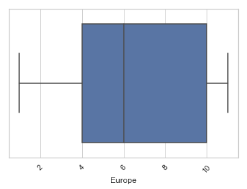

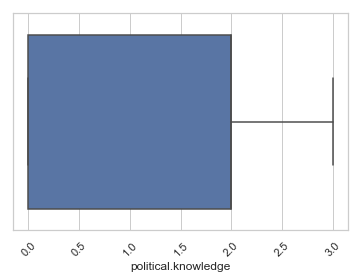

```python
# df_num["economic.cond.national","economic.cond.household"].boxplot(figsize=(20,3))
for feature in df_num.columns:
    sns.boxplot(df_num[feature])
    plt.xticks(rotation=45)
    plt.show()
```

###### Inference

From the above boxplot, we can infer that, the outliers are present in "economic.cond.national","economic.cond.household". It is not needed to treat the outlier.

### 1.3 Encode the data (having string values) for Modelling. Is Scaling necessary here or not? Data Split: Split the data into train and test (70:30)

Since Age is in different scale with other independent variables, scaling is needed.

```python
from scipy.stats import zscore
df_num_scaled=df_num.apply(zscore)
df_num_scaled.head()
```

|  | Unnamed: 0 | age | economic.cond.national | economic.cond.household | Blair | Hague | Europe | political.knowledge |
| --- | --- | --- | --- | --- | --- | --- | --- | --- |
| 0 | -1.730915 | -0.711973 | -0.279218 | -0.150948 | 0.566716 | -1.419886 | -1.434426 | 0.422643 |
| 1 | -1.728644 | -1.157661 | 0.856268 | 0.924730 | 0.566716 | 1.018544 | -0.524358 | 0.422643 |
| 2 | -1.726372 | -1.221331 | 0.856268 | 0.924730 | 1.418187 | -0.607076 | -1.131070 | 0.422643 |
| 3 | -1.724101 | -1.921698 | 0.856268 | -1.226625 | -1.136225 | -1.419886 | -0.827714 | -1.424148 |
| 4 | -1.721829 | -0.839313 | -1.414704 | -1.226625 | -1.987695 | -1.419886 | -0.221002 | 0.422643 |

```python
new_df_scaled = pd.concat([df_cat, df_num_scaled], axis=1)
new_df_scaled.head()
```

|  | vote | gender | Unnamed: 0 | age | economic.cond.national | economic.cond.household | Blair | Hague | Europe | political.knowledge |
| --- | --- | --- | --- | --- | --- | --- | --- | --- | --- | --- |
| 0 | Labour | female | -1.730915 | -0.711973 | -0.279218 | -0.150948 | 0.566716 | -1.419886 | -1.434426 | 0.422643 |
| 1 | Labour | male | -1.728644 | -1.157661 | 0.856268 | 0.924730 | 0.566716 | 1.018544 | -0.524358 | 0.422643 |
| 2 | Labour | male | -1.726372 | -1.221331 | 0.856268 | 0.924730 | 1.418187 | -0.607076 | -1.131070 | 0.422643 |
| 3 | Labour | female | -1.724101 | -1.921698 | 0.856268 | -1.226625 | -1.136225 | -1.419886 | -0.827714 | -1.424148 |
| 4 | Labour | male | -1.721829 | -0.839313 | -1.414704 | -1.226625 | -1.987695 | -1.419886 | -0.221002 | 0.422643 |

```python
new_df_scaled = new_df_scaled.drop("Unnamed: 0", axis=1)
new_df_scaled.head()
```

|  | vote | gender | age | economic.cond.national | economic.cond.household | Blair | Hague | Europe | political.knowledge |
| --- | --- | --- | --- | --- | --- | --- | --- | --- | --- |
| 0 | Labour | female | -0.711973 | -0.279218 | -0.150948 | 0.566716 | -1.419886 | -1.434426 | 0.422643 |
| 1 | Labour | male | -1.157661 | 0.856268 | 0.924730 | 0.566716 | 1.018544 | -0.524358 | 0.422643 |
| 2 | Labour | male | -1.221331 | 0.856268 | 0.924730 | 1.418187 | -0.607076 | -1.131070 | 0.422643 |
| 3 | Labour | female | -1.921698 | 0.856268 | -1.226625 | -1.136225 | -1.419886 | -0.827714 | -1.424148 |
| 4 | Labour | male | -0.839313 | -1.414704 | -1.226625 | -1.987695 | -1.419886 | -0.221002 | 0.422643 |

```python
for column in new_df_scaled.columns:
    print(column.upper(),': ',new_df_scaled[column].nunique())
    print(df[column].value_counts().sort_values())
    print('\n')
```

```
VOTE :  2
Conservative     462
Labour          1063
Name: vote, dtype: int64


GENDER :  2
male      713
female    812
Name: gender, dtype: int64


AGE :  70
93     1
90     1
```

[output cut: 119 more lines]

```python
df_encoded = pd.get_dummies(new_df_scaled, columns=['gender','vote'],drop_first=True)
df_encoded.head()
```

|  | age | economic.cond.national | economic.cond.household | Blair | Hague | Europe | political.knowledge | gender_male | vote_Labour |
| --- | --- | --- | --- | --- | --- | --- | --- | --- | --- |
| 0 | -0.711973 | -0.279218 | -0.150948 | 0.566716 | -1.419886 | -1.434426 | 0.422643 | 0 | 1 |
| 1 | -1.157661 | 0.856268 | 0.924730 | 0.566716 | 1.018544 | -0.524358 | 0.422643 | 1 | 1 |
| 2 | -1.221331 | 0.856268 | 0.924730 | 1.418187 | -0.607076 | -1.131070 | 0.422643 | 1 | 1 |
| 3 | -1.921698 | 0.856268 | -1.226625 | -1.136225 | -1.419886 | -0.827714 | -1.424148 | 0 | 1 |
| 4 | -0.839313 | -1.414704 | -1.226625 | -1.987695 | -1.419886 | -0.221002 | 0.422643 | 1 | 1 |

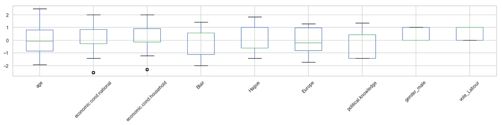

```python
df_encoded.boxplot(figsize=(20,3))
plt.xticks(rotation=45)
plt.show()
```

```python
X = df_encoded.drop('vote_Labour', axis=1)

y = df_encoded[['vote_Labour']]
X.head()
```

|  | age | economic.cond.national | economic.cond.household | Blair | Hague | Europe | political.knowledge | gender_male |
| --- | --- | --- | --- | --- | --- | --- | --- | --- |
| 0 | -0.711973 | -0.279218 | -0.150948 | 0.566716 | -1.419886 | -1.434426 | 0.422643 | 0 |
| 1 | -1.157661 | 0.856268 | 0.924730 | 0.566716 | 1.018544 | -0.524358 | 0.422643 | 1 |
| 2 | -1.221331 | 0.856268 | 0.924730 | 1.418187 | -0.607076 | -1.131070 | 0.422643 | 1 |
| 3 | -1.921698 | 0.856268 | -1.226625 | -1.136225 | -1.419886 | -0.827714 | -1.424148 | 0 |
| 4 | -0.839313 | -1.414704 | -1.226625 | -1.987695 | -1.419886 | -0.221002 | 0.422643 | 1 |

```python
X_train, X_test, y_train, y_test = train_test_split(X, y, test_size=0.3 , random_state=42)
```

The Target variable and other variables are separated and training and testing data are splitted using train_test_split function in the ratio of 70:30.

```python
X_train.head()
```

|  | age | economic.cond.national | economic.cond.household | Blair | Hague | Europe | political.knowledge | gender_male |
| --- | --- | --- | --- | --- | --- | --- | --- | --- |
| 1372 | 1.261787 | 0.856268 | 0.924730 | 0.566716 | -0.607076 | -1.434426 | 0.422643 | 1 |
| 126 | -0.520964 | 0.856268 | -0.150948 | 0.566716 | 1.018544 | -1.434426 | 0.422643 | 1 |
| 327 | 1.452797 | -0.279218 | -0.150948 | -1.136225 | 1.018544 | 0.689066 | 0.422643 | 1 |
| 292 | -0.202616 | -0.279218 | -0.150948 | 0.566716 | -0.607076 | -0.221002 | -0.500753 | 0 |
| 1058 | -1.093992 | -0.279218 | 0.924730 | 0.566716 | -0.607076 | 0.385710 | -1.424148 | 0 |

### 1.4 Apply Logistic Regression and LDA (linear discriminant analysis). (4 marks)

##### Logistic Regression

```python
grid={'penalty':['l1','l2','none'],
      'solver':['lbfgs', 'liblinear'],
      'tol':[0.0001,0.000001]}
```

```python
from sklearn.linear_model import LogisticRegression
model = LogisticRegression(max_iter=100000)
```

```python
grid_search = GridSearchCV(estimator = model, param_grid = grid, cv = 3)
```

```python
grid_search.fit(X_train, y_train)
```

[output not shown]

[output cut: 27 more lines]

[output not shown]

```
GridSearchCV(cv=3, estimator=LogisticRegression(max_iter=100000),
             param_grid={'penalty': ['l1', 'l2', 'none'],
                         'solver': ['lbfgs', 'liblinear'],
                         'tol': [0.0001, 1e-06]})
```

```python
grid_search.best_params_
```

```
{'penalty': 'l1', 'solver': 'liblinear', 'tol': 0.0001}
```

```python
best_model = grid_search.best_estimator_
best_model
```

```
LogisticRegression(max_iter=100000, penalty='l1', solver='liblinear')
```

```python
ytrain_predict = best_model.predict(X_train)
ytest_predict = best_model.predict(X_test)
ytrain_predict
```

```
array([1, 1, 0, ..., 0, 1, 1], dtype=uint8)
```

```python
ytest_predict_prob=best_model.predict_proba(X_test)
pd.DataFrame(ytest_predict_prob).head()
```

|  | 0 | 1 |
| --- | --- | --- |
| 0 | 0.020830 | 0.979170 |
| 1 | 0.033056 | 0.966944 |
| 2 | 0.018667 | 0.981333 |
| 3 | 0.436583 | 0.563417 |
| 4 | 0.287090 | 0.712910 |

```python
confusion_matrix(y_train,ytrain_predict)
```

```
array([[228, 101],
       [ 68, 670]], dtype=int64)
```

```python
confusion_matrix(y_test, ytest_predict)
```

```
array([[ 79,  54],
       [ 33, 292]], dtype=int64)
```

```python
print(classification_report(y_train, ytrain_predict),'\n');
```

```
              precision    recall  f1-score   support

           0       0.77      0.69      0.73       329
           1       0.87      0.91      0.89       738

    accuracy                           0.84      1067
   macro avg       0.82      0.80      0.81      1067
weighted avg       0.84      0.84      0.84      1067
```

```python
print(classification_report(y_test, ytest_predict),'\n');
```

```
              precision    recall  f1-score   support

           0       0.71      0.59      0.64       133
           1       0.84      0.90      0.87       325

    accuracy                           0.81       458
   macro avg       0.77      0.75      0.76       458
weighted avg       0.80      0.81      0.80       458
```

```
AUC: 0.895
```

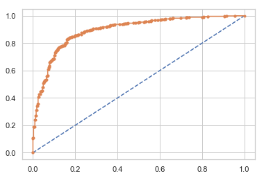

```python
# predict probabilities
probs = best_model.predict_proba(X_train)
# keep probabilities for the positive outcome only
probs = probs[:, 1]
# calculate AUC
from sklearn.metrics import roc_auc_score
lr_train_auc = roc_auc_score(y_train, probs)
print('AUC: %.3f' % lr_train_auc)
# calculate roc curve
from sklearn.metrics import roc_curve
fpr, tpr, thresholds = roc_curve(y_train, probs)
plt.plot([0, 1], [0, 1], linestyle='--')
# plot the roc curve for the model
plt.plot(fpr, tpr, marker='.')
# show the plot
plt.show()
```

```
AUC: 0.872
```

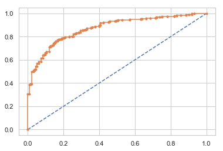

```python
# AUC and ROC for the test data


# predict probabilities
probs = best_model.predict_proba(X_test)
# keep probabilities for the positive outcome only
probs = probs[:, 1]
# calculate AUC
from sklearn.metrics import roc_auc_score
lr_test_auc = roc_auc_score(y_test, probs)
print('AUC: %.3f' % lr_test_auc)
# calculate roc curve
from sklearn.metrics import roc_curve
fpr, tpr, thresholds = roc_curve(y_test, probs)
plt.plot([0, 1], [0, 1], linestyle='--')
# plot the roc curve for the model
plt.plot(fpr, tpr, marker='.')
# show the plot
plt.show()
```

```python
lr_metrics=classification_report(y_train, ytrain_predict,output_dict=True)
dftr=pd.DataFrame(lr_metrics).transpose()
lr_train_f1=round(dftr.loc["1"][2],2)
lr_train_recall=round(dftr.loc["1"][1],2)
lr_train_precision=round(dftr.loc["1"][0],2)
lr_train_acc=round(dftr.loc["accuracy"][0],2)

print ('lr_train_precision ',lr_train_precision)
print ('lr_train_recall ',lr_train_recall)
print ('lr_train_f1 ',lr_train_f1)
print ('lr_train_acc ',lr_train_acc)
```

```
lr_train_precision  0.89
lr_train_recall  0.87
lr_train_f1  0.91
lr_train_acc  0.84
```

```python
lr_metrics=classification_report(y_test, ytest_predict,output_dict=True)
dft=pd.DataFrame(lr_metrics).transpose()
lr_test_f1=round(dft.loc["1"][2],2)
lr_test_recall=round(dft.loc["1"][1],2)
lr_test_precision=round(dft.loc["1"][0],2)
lr_test_acc=round(dft.loc["accuracy"][0],2)
print ('lr_test_precision ',lr_test_precision)
print ('lr_test_recall ',lr_test_recall)
print ('lr_test_f1 ',lr_test_f1)
print ('lr_test_acc',lr_test_acc)
```

```
lr_test_precision  0.87
lr_test_recall  0.84
lr_test_f1  0.9
lr_test_acc 0.81
```

##### LDA

```python
clf = LinearDiscriminantAnalysis()
model=clf.fit(X_train,y_train)
model
```

```
LinearDiscriminantAnalysis()
```

```python
# Predict it
pred_class_train = model.predict(X_train)
pred_class_train
```

```
array([1, 1, 0, ..., 0, 1, 1], dtype=uint8)
```

```python
pred_class_test = model.predict(X_test)
pred_class_test
```

```
array([1, 1, 1, 1, 1, 1, 1, 0, 1, 1, 1, 1, 0, 1, 1, 1, 1, 1, 1, 1, 0, 0,
       1, 1, 1, 1, 0, 1, 1, 1, 0, 1, 1, 0, 1, 1, 1, 0, 0, 1, 1, 1, 0, 1,
       1, 1, 1, 0, 1, 1, 1, 1, 1, 1, 1, 1, 1, 1, 1, 0, 1, 0, 0, 1, 1, 1,
       1, 1, 1, 1, 1, 1, 0, 1, 1, 0, 1, 1, 1, 1, 1, 1, 0, 1, 1, 1, 0, 1,
       1, 1, 0, 1, 1, 1, 0, 0, 1, 1, 1, 1, 1, 0, 1, 0, 1, 1, 1, 0, 0, 1,
       1, 0, 1, 0, 0, 1, 1, 1, 1, 1, 1, 1, 1, 1, 1, 0, 1, 0, 1, 0, 1, 0,
       0, 1, 0, 1, 1, 1, 1, 1, 0, 1, 1, 1, 1, 1, 0, 1, 1, 1, 1, 1, 1, 0,
       0, 1, 1, 1, 1, 0, 1, 1, 0, 1, 0, 1, 1, 1, 1, 0, 1, 1, 1, 0, 0, 1,
       1, 1, 1, 1, 1, 1, 1, 0, 1, 1, 1, 1, 0, 1, 0, 1, 1, 1, 1, 0, 1, 1,
       1, 1, 1, 1, 1, 1, 1, 1, 1, 0, 1, 1, 1, 1, 1, 1, 1, 0, 1, 1, 1, 0,
       1, 1, 1, 1, 0, 1, 0, 1, 0, 0, 1, 0, 0, 0, 1, 0, 1, 1, 1, 1, 1, 1,
       1, 1, 1, 1, 1, 1, 1, 1, 0, 1, 0, 0, 1, 1, 1, 1, 1, 1, 1, 1, 0, 0,
       1, 1, 1, 0, 1, 1, 1, 0, 0, 0, 0, 1, 1, 1, 1, 1, 1, 1, 1, 1, 0, 1,
       0, 1, 0, 1, 1, 1, 1, 0, 1, 1, 1, 0, 0, 1, 1, 1, 1, 1, 1, 1, 0, 1,
       0, 1, 1, 0, 0, 1, 1, 0, 1, 1, 0, 0, 1, 1, 1, 0, 1, 1, 1, 1, 0, 1,
       0, 0, 0, 1, 1, 1, 1, 1, 0, 1, 1, 1, 0, 1, 1, 1, 0, 1, 0, 1, 1, 1,
       1, 0, 1, 1, 1, 1, 1, 1, 1, 1, 0, 1, 1, 0, 1, 1, 1, 1, 1, 0, 1, 0,
       1, 1, 1, 1, 1, 0, 1, 1, 1, 0, 1, 1, 0, 0, 1, 0, 0, 1, 1, 1, 1, 1,
       1, 0, 1, 0, 1, 0, 1, 0, 1, 1, 1, 1, 0, 0, 1, 1, 1, 1, 1, 0, 0, 1,
       1, 0, 0, 0, 1, 1, 1, 1, 1, 1, 1, 1, 0, 1, 1, 1, 0, 1, 0, 1, 0, 0,
       0, 0, 1, 1, 1, 1, 1, 0, 1, 1, 1, 1, 1, 1, 1, 1, 1, 1], dtype=uint8)
```

```python
pred_prob_train = model.predict_proba(X_train)

# Test Data Probability Prediction
pred_prob_test = model.predict_proba(X_test)
```

```python
model.score(X_train,y_train)
```

```
0.8425492033739457
```

```python
print(classification_report(y_train, pred_class_train))
```

```
              precision    recall  f1-score   support

           0       0.77      0.70      0.73       329
           1       0.87      0.91      0.89       738

    accuracy                           0.84      1067
   macro avg       0.82      0.80      0.81      1067
weighted avg       0.84      0.84      0.84      1067
```

```python
confusion_matrix(y_train, pred_class_train)
```

```
array([[229, 100],
       [ 68, 670]], dtype=int64)
```

```python
model.score(X_test,y_test)
```

```
0.8122270742358079
```

```python
print(classification_report(y_test, pred_class_test))
```

```
              precision    recall  f1-score   support

           0       0.69      0.63      0.66       133
           1       0.85      0.89      0.87       325

    accuracy                           0.81       458
   macro avg       0.77      0.76      0.77       458
weighted avg       0.81      0.81      0.81       458
```

```python
confusion_matrix(y_test, pred_class_test)
```

```
array([[ 84,  49],
       [ 37, 288]], dtype=int64)
```

```
AUC: 0.895
```

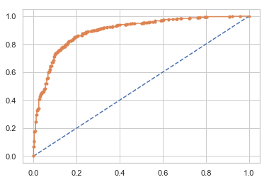

```python
# predict probabilities
probs = model.predict_proba(X_train)
# keep probabilities for the positive outcome only
probs = probs[:, 1]
# calculate AUC
from sklearn.metrics import roc_auc_score
lda_train_auc = roc_auc_score(y_train, probs)
print('AUC: %.3f' % lr_train_auc)
# calculate roc curve
from sklearn.metrics import roc_curve
fpr, tpr, thresholds = roc_curve(y_train, probs)
plt.plot([0, 1], [0, 1], linestyle='--')
# plot the roc curve for the model
plt.plot(fpr, tpr, marker='.')
# show the plot
plt.show()
```

```
AUC: 0.872
```

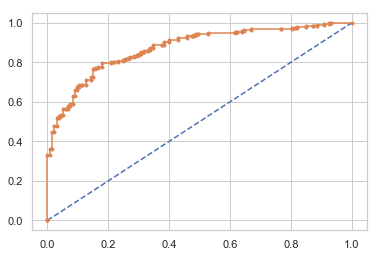

```python
# AUC and ROC for the test data


# predict probabilities
probs = model.predict_proba(X_test)
# keep probabilities for the positive outcome only
probs = probs[:, 1]
# calculate AUC
from sklearn.metrics import roc_auc_score
lda_test_auc = roc_auc_score(y_test, probs)
print('AUC: %.3f' % lr_test_auc)
# calculate roc curve
from sklearn.metrics import roc_curve
fpr, tpr, thresholds = roc_curve(y_test, probs)
plt.plot([0, 1], [0, 1], linestyle='--')
# plot the roc curve for the model
plt.plot(fpr, tpr, marker='.')
# show the plot
plt.show()
```

```python
lda_metrics=classification_report(y_train, pred_class_train,output_dict=True)
dftra=pd.DataFrame(lda_metrics).transpose()
lda_train_f1=round(dftra.loc["1"][2],2)
lda_train_recall=round(dftra.loc["1"][1],2)
lda_train_precision=round(dftra.loc["1"][0],2)
lda_train_acc=round(dftra.loc["accuracy"][0],2)
print ('lda_train_precision ',lda_train_precision)
print ('lda_train_recall ',lda_train_recall)
print ('lda_train_f1 ',lda_train_f1)
print ('lda_train_f1 ',lda_train_acc)
```

```
lda_train_precision  0.89
lda_train_recall  0.87
lda_train_f1  0.91
lda_train_f1  0.84
```

```python
lda_metrics=classification_report(y_test, pred_class_test,output_dict=True)
dfte=pd.DataFrame(lda_metrics).transpose()
lda_test_f1=round(dfte.loc["1"][2],2)
lda_test_recall=round(dfte.loc["1"][1],2)
lda_test_precision=round(dfte.loc["1"][0],2)
lda_test_acc=round(dfte.loc["accuracy"][0],2)
print ('lda_train_precision ',lda_test_precision)
print ('lda_train_recall ',lda_test_recall)
print ('lda_train_f1 ',lda_test_f1)
print ('lda_train_acc ',lda_test_acc)
```

```
lda_train_precision  0.87
lda_train_recall  0.85
lda_train_f1  0.89
lda_train_acc  0.81
```

```python
index=['Accuracy', 'AUC', 'Recall','Precision','F1 Score']
data1 = pd.DataFrame({'LR Train':[lr_train_acc,lr_train_auc,lr_train_recall,lr_train_precision,lr_train_f1],
        'LR Test':[lr_test_acc,lr_test_auc,lr_test_recall,lr_test_precision,lr_test_f1],
       'LDA Train':[lda_train_acc,lda_train_auc,lda_train_recall,lda_train_precision,lda_train_f1],
        'LDA Test':[lda_test_acc,lda_test_auc,lda_test_recall,lda_test_precision,lda_test_f1],},index=index)
round(data1,2)
```

|  | LR Train | LR Test | LDA Train | LDA Test |
| --- | --- | --- | --- | --- |
| Accuracy | 0.84 | 0.81 | 0.84 | 0.81 |
| AUC | 0.89 | 0.87 | 0.89 | 0.87 |
| Recall | 0.87 | 0.84 | 0.87 | 0.85 |
| Precision | 0.89 | 0.87 | 0.89 | 0.87 |
| F1 Score | 0.91 | 0.90 | 0.91 | 0.89 |

From the above table, we can infer that the accuracy and AUC for train and test data in logistic regression and LDA are same. recall,precision and F1 score are close to each other in both training and testing data. From the output, Logistic regression and LDA gives good result.

### 1.5 Apply KNN Model and Naïve Bayes Model. Interpret the results. (4 marks)

##### K-Nearest Neighbors Classifier

```python
from sklearn.neighbors import KNeighborsClassifier
NNH = KNeighborsClassifier(n_neighbors= 7 , weights = 'distance' )
```

```python
NNH.fit(X_train, y_train)
```

```
KNeighborsClassifier(n_neighbors=7, weights='distance')
```

```python
train_predict_NNH = NNH.predict(X_train)
NNH.score(X_train, y_train)
```

```
0.9990627928772259
```

```python
confusion_matrix(y_train, train_predict_NNH)
```

```
array([[329,   0],
       [  1, 737]], dtype=int64)
```

```python
print(classification_report(y_train, train_predict_NNH))
```

```
              precision    recall  f1-score   support

           0       1.00      1.00      1.00       329
           1       1.00      1.00      1.00       738

    accuracy                           1.00      1067
   macro avg       1.00      1.00      1.00      1067
weighted avg       1.00      1.00      1.00      1067
```

```
AUC: 1.000
```

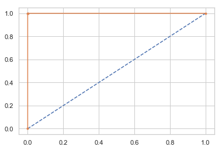

```python
# predict probabilities
probs = NNH.predict_proba(X_train)
# keep probabilities for the positive outcome only
probs = probs[:, 1]
# calculate AUC
from sklearn.metrics import roc_auc_score
NNH_train_auc = roc_auc_score(y_train, probs)
print('AUC: %.3f' % NNH_train_auc)
# calculate roc curve
from sklearn.metrics import roc_curve
fpr, tpr, thresholds = roc_curve(y_train, probs)
plt.plot([0, 1], [0, 1], linestyle='--')
# plot the roc curve for the model
plt.plot(fpr, tpr, marker='.')
# show the plot
plt.show()
```

```python
nnh_metrics=classification_report(y_train, train_predict_NNH,output_dict=True)
dftr=pd.DataFrame(nnh_metrics).transpose()
nnh_train_f1=round(dftr.loc["1"][2],2)
nnh_train_recall=round(dftr.loc["1"][1],2)
nnh_train_precision=round(dftr.loc["1"][0],2)
nnh_train_acc=round(dftr.loc["accuracy"][0],2)

print ('KNN train_precision ',nnh_train_precision)
print ('KNN train_recall ',nnh_train_recall)
print ('KNN train_f1 ',nnh_train_f1)
print ('KNN train_acc ',nnh_train_acc)
```

```
KNN train_precision  1.0
KNN train_recall  1.0
KNN train_f1  1.0
KNN train_acc  1.0
```

```python
test_predict_NNH = NNH.predict(X_test)
NNH.score(X_test, y_test)
```

```
0.8013100436681223
```

```python
confusion_matrix(y_test, test_predict_NNH)
```

```
array([[ 88,  45],
       [ 46, 279]], dtype=int64)
```

```python
print(classification_report(y_test, test_predict_NNH))
```

```
              precision    recall  f1-score   support

           0       0.66      0.66      0.66       133
           1       0.86      0.86      0.86       325

    accuracy                           0.80       458
   macro avg       0.76      0.76      0.76       458
weighted avg       0.80      0.80      0.80       458
```

```
AUC: 0.841
```

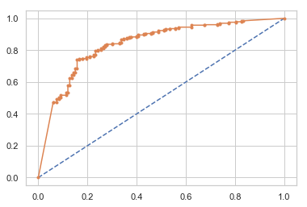

```python
# predict probabilities
probs = NNH.predict_proba(X_test)
# keep probabilities for the positive outcome only
probs = probs[:, 1]
# calculate AUC
from sklearn.metrics import roc_auc_score
NNH_test_auc = roc_auc_score(y_test, probs)
print('AUC: %.3f' % NNH_test_auc)
# calculate roc curve
from sklearn.metrics import roc_curve
fpr, tpr, thresholds = roc_curve(y_test, probs)
plt.plot([0, 1], [0, 1], linestyle='--')
# plot the roc curve for the model
plt.plot(fpr, tpr, marker='.')
# show the plot
plt.show()
```

```python
nnh_metrics=classification_report(y_test, test_predict_NNH,output_dict=True)
dftr=pd.DataFrame(nnh_metrics).transpose()
nnh_test_f1=round(dftr.loc["1"][2],2)
nnh_test_recall=round(dftr.loc["1"][1],2)
nnh_test_precision=round(dftr.loc["1"][0],2)
nnh_test_acc=round(dftr.loc["accuracy"][0],2)

print ('nnh_test_precision ',nnh_test_precision)
print ('nnh_test_recall ',nnh_test_recall)
print ('nnh_test_f1 ',nnh_test_f1)
print ('nnh_test_acc ',nnh_test_acc)
```

```
nnh_test_precision  0.86
nnh_test_recall  0.86
nnh_test_f1  0.86
nnh_test_acc  0.8
```

##### Naive Bayes algorithm

```python
from sklearn.naive_bayes import GaussianNB # using Gaussian algorithm from Naive Bayes

# creatw the model
NBA = GaussianNB()

NBA.fit(X_train, y_train)
```

```
GaussianNB()
```

```python
NBA_train_predict = NBA.predict(X_train)
```

```python
NBA.score(X_train, y_train)
```

```
0.837863167760075
```

```python
confusion_matrix(y_train, NBA_train_predict)
```

```
array([[237,  92],
       [ 81, 657]], dtype=int64)
```

```python
print(classification_report(y_train, NBA_train_predict))
```

```
              precision    recall  f1-score   support

           0       0.75      0.72      0.73       329
           1       0.88      0.89      0.88       738

    accuracy                           0.84      1067
   macro avg       0.81      0.81      0.81      1067
weighted avg       0.84      0.84      0.84      1067
```

```
AUC: 0.892
```

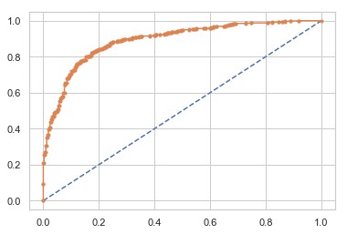

```python
# predict probabilities
probs = NBA.predict_proba(X_train)
# keep probabilities for the positive outcome only
probs = probs[:, 1]
# calculate AUC
from sklearn.metrics import roc_auc_score
NBA_train_auc = roc_auc_score(y_train, probs)
print('AUC: %.3f' % NBA_train_auc)
# calculate roc curve
from sklearn.metrics import roc_curve
fpr, tpr, thresholds = roc_curve(y_train, probs)
plt.plot([0, 1], [0, 1], linestyle='--')
# plot the roc curve for the model
plt.plot(fpr, tpr, marker='.')
# show the plot
plt.show()
```

```python
nba_metrics=classification_report(y_train, NBA_train_predict,output_dict=True)
dftr=pd.DataFrame(nba_metrics).transpose()
nba_train_f1=round(dftr.loc["1"][2],2)
nba_train_recall=round(dftr.loc["1"][1],2)
nba_train_precision=round(dftr.loc["1"][0],2)
nba_train_acc=round(dftr.loc["accuracy"][0],2)

print ('nba_train_precision ',nba_train_precision)
print ('nba_train_recall ',nba_train_recall)
print ('nba_train_f1 ',nba_train_f1)
print ('nba_train_acc ',nba_train_acc)
```

```
nba_train_precision  0.88
nba_train_recall  0.88
nba_train_f1  0.89
nba_train_acc  0.84
```

```python
NBA_test_predict = NBA.predict(X_test)
```

```python
NBA.score(X_test, y_test)
```

```
0.8144104803493449
```

```python
confusion_matrix(y_test, NBA_test_predict)
```

```
array([[ 87,  46],
       [ 39, 286]], dtype=int64)
```

```python
print(classification_report(y_test, NBA_test_predict))
```

```
              precision    recall  f1-score   support

           0       0.69      0.65      0.67       133
           1       0.86      0.88      0.87       325

    accuracy                           0.81       458
   macro avg       0.78      0.77      0.77       458
weighted avg       0.81      0.81      0.81       458
```

```
AUC: 0.867
```

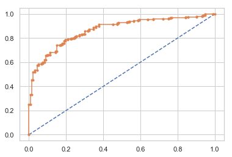

```python
# predict probabilities
probs = NBA.predict_proba(X_test)
# keep probabilities for the positive outcome only
probs = probs[:, 1]
# calculate AUC
from sklearn.metrics import roc_auc_score
NBA_test_auc = roc_auc_score(y_test, probs)
print('AUC: %.3f' % NBA_test_auc)
# calculate roc curve
from sklearn.metrics import roc_curve
fpr, tpr, thresholds = roc_curve(y_test, probs)
plt.plot([0, 1], [0, 1], linestyle='--')
# plot the roc curve for the model
plt.plot(fpr, tpr, marker='.')
# show the plot
plt.show()
```

```python
nba_metrics=classification_report(y_test, NBA_test_predict,output_dict=True)
dftr=pd.DataFrame(nba_metrics).transpose()
nba_test_f1=round(dftr.loc["1"][2],2)
nba_test_recall=round(dftr.loc["1"][1],2)
nba_test_precision=round(dftr.loc["1"][0],2)
nba_test_acc=round(dftr.loc["accuracy"][0],2)

print ('nba_test_precision ',nba_test_precision)
print ('nba_test_recall ',nba_test_recall)
print ('nba_test_f1 ',nba_test_f1)
print ('nba_test_acc ',nba_test_acc)
```

```
nba_test_precision  0.87
nba_test_recall  0.86
nba_test_f1  0.88
nba_test_acc  0.81
```

```python
index=['Accuracy', 'AUC', 'Recall','Precision','F1 Score']
data2 = pd.DataFrame({'NNH Train':[nnh_train_acc,NNH_train_auc,nnh_train_recall,nnh_train_precision,nnh_train_f1],
        'NNH Test':[nnh_test_acc,NNH_test_auc,nnh_test_recall,nnh_test_precision,nnh_test_f1],
       'NBA Train':[nba_train_acc,NBA_train_auc,nba_train_recall,nba_train_precision,nba_train_f1],
        'NBA Test':[nba_test_acc,NBA_test_auc,nba_test_recall,nba_test_precision,nba_test_f1],},index=index)
round(data2,2)
```

|  | NNH Train | NNH Test | NBA Train | NBA Test |
| --- | --- | --- | --- | --- |
| Accuracy | 1.0 | 0.80 | 0.84 | 0.81 |
| AUC | 1.0 | 0.84 | 0.89 | 0.87 |
| Recall | 1.0 | 0.86 | 0.88 | 0.86 |
| Precision | 1.0 | 0.86 | 0.88 | 0.87 |
| F1 Score | 1.0 | 0.86 | 0.89 | 0.88 |

From the above table, we can infer that Naive Bayes Algorithm gives the better result for testing data.

### 1.6 Model Tuning, Bagging (Random Forest should be applied for Bagging), and Boosting. (7 marks)

```python
from sklearn.tree import DecisionTreeClassifier
from sklearn import tree
from IPython.display import Image
```

```python
param_grid_dtcl = {
    'criterion': ['gini'],
    'max_depth': [3,5,7,10,20,30,50],
    'min_samples_leaf': [20,30,40,50,100,150],
    'min_samples_split': [150,300,450],
}
```

```python
dtcl = DecisionTreeClassifier(random_state=42)

grid_search_dtcl = GridSearchCV(estimator = dtcl, param_grid = param_grid_dtcl, cv = 3)
```

```python
grid_search_dtcl.fit(X_train, y_train)
```

```
GridSearchCV(cv=3, estimator=DecisionTreeClassifier(random_state=42),
             param_grid={'criterion': ['gini'],
                         'max_depth': [3, 5, 7, 10, 20, 30, 50],
                         'min_samples_leaf': [20, 30, 40, 50, 100, 150],
                         'min_samples_split': [150, 300, 450]})
```

```python
grid_search_dtcl.best_params_
```

```
{'criterion': 'gini',
 'max_depth': 3,
 'min_samples_leaf': 20,
 'min_samples_split': 150}
```

```python
best_grid_dtcl = grid_search_dtcl.best_estimator_
```

```python
ytrain_predict_dtcl = best_grid_dtcl.predict(X_train)
ytest_predict_dtcl = best_grid_dtcl.predict(X_test)
```

```python
print(best_grid_dtcl.score(X_train, y_train))
```

```
0.8125585754451734
```

```python
print(best_grid_dtcl.score(X_test, y_test))
```

```
0.7816593886462883
```

```python
dtcl_train = confusion_matrix(y_train, ytrain_predict_dtcl)
dtcl_train
```

```
array([[213, 116],
       [ 84, 654]], dtype=int64)
```

```python
dtcl_test = confusion_matrix(y_test, ytest_predict_dtcl)
dtcl_test
```

```
array([[ 76,  57],
       [ 43, 282]], dtype=int64)
```

```python
print(classification_report(y_train,ytrain_predict_dtcl),"\n")
```

```
              precision    recall  f1-score   support

           0       0.72      0.65      0.68       329
           1       0.85      0.89      0.87       738

    accuracy                           0.81      1067
   macro avg       0.78      0.77      0.77      1067
weighted avg       0.81      0.81      0.81      1067
```

```python
print(classification_report(y_test,ytest_predict_dtcl),"\n")
```

```
              precision    recall  f1-score   support

           0       0.64      0.57      0.60       133
           1       0.83      0.87      0.85       325

    accuracy                           0.78       458
   macro avg       0.74      0.72      0.73       458
weighted avg       0.78      0.78      0.78       458
```

```
AUC: 0.865
```

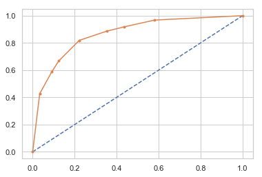

```python
# predict probabilities
probs = best_grid_dtcl.predict_proba(X_train)
# keep probabilities for the positive outcome only
probs = probs[:, 1]
# calculate AUC
from sklearn.metrics import roc_auc_score
dtcl_train_auc = roc_auc_score(y_train, probs)
print('AUC: %.3f' % dtcl_train_auc)
# calculate roc curve
from sklearn.metrics import roc_curve
fpr, tpr, thresholds = roc_curve(y_train, probs)
plt.plot([0, 1], [0, 1], linestyle='--')
# plot the roc curve for the model
plt.plot(fpr, tpr, marker='.')
# show the plot
plt.show()
```

```
AUC: 0.837
```

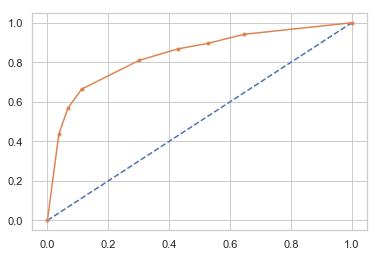

```python
# predict probabilities
probs = best_grid_dtcl.predict_proba(X_test)
# keep probabilities for the positive outcome only
probs = probs[:, 1]
# calculate AUC
from sklearn.metrics import roc_auc_score
DTCL_test_auc = roc_auc_score(y_test, probs)
print('AUC: %.3f' % DTCL_test_auc)
# calculate roc curve
from sklearn.metrics import roc_curve
fpr, tpr, thresholds = roc_curve(y_test, probs)
plt.plot([0, 1], [0, 1], linestyle='--')
# plot the roc curve for the model
plt.plot(fpr, tpr, marker='.')
# show the plot
plt.show()
```

```python
nba_metrics=classification_report(y_train, ytrain_predict_dtcl,output_dict=True)
dftr=pd.DataFrame(nba_metrics).transpose()
dtcl_train_f1=round(dftr.loc["1"][2],2)
dtcl_train_recall=round(dftr.loc["1"][1],2)
dtcl_train_precision=round(dftr.loc["1"][0],2)
dtcl_train_acc=round(dftr.loc["accuracy"][0],2)

print ('dtcl_train_precision ',dtcl_train_precision)
print ('dtcl_train_recall ',dtcl_train_recall)
print ('dtcl_train_f1 ',dtcl_train_f1)
print ('dtcl_train_acc ',dtcl_train_acc)
```

```
dtcl_train_precision  0.87
dtcl_train_recall  0.85
dtcl_train_f1  0.89
dtcl_train_acc  0.81
```

```python
nba_metrics=classification_report(y_test, ytest_predict_dtcl,output_dict=True)
dftr=pd.DataFrame(nba_metrics).transpose()
dtcl_test_f1=round(dftr.loc["1"][2],2)
dtcl_test_recall=round(dftr.loc["1"][1],2)
dtcl_test_precision=round(dftr.loc["1"][0],2)
dtcl_test_acc=round(dftr.loc["accuracy"][0],2)

print ('dtcl_test_precision ',dtcl_test_precision)
print ('dtcl_test_recall ',dtcl_test_recall)
print ('dtcl_test_f1 ',dtcl_test_f1)
print ('dtcl_test_acc ',dtcl_test_acc)
```

```
dtcl_test_precision  0.85
dtcl_test_recall  0.83
dtcl_test_f1  0.87
dtcl_test_acc  0.78
```

```python
print (pd.DataFrame(best_grid_dtcl.feature_importances_, columns = ["Imp"], index = X_train.columns).sort_values("Imp",ascending=False))
```

```
                              Imp
Hague                    0.516214
Blair                    0.319860
Europe                   0.094734
age                      0.069192
economic.cond.national   0.000000
economic.cond.household  0.000000
political.knowledge      0.000000
gender_male              0.000000
```

##### Bagging (Using Random Forest clasifier)

```python
from sklearn.ensemble import RandomForestClassifier
rfcl = RandomForestClassifier(n_estimators = 50, random_state=42,n_jobs=-1,max_depth=7,oob_score=True)
rfcl = rfcl.fit(X_train, y_train)
```

```python
from sklearn.ensemble import BaggingClassifier

bgcl = BaggingClassifier(base_estimator=rfcl)
bgcl
```

```
BaggingClassifier(base_estimator=RandomForestClassifier(max_depth=7,
                                                        n_estimators=50,
                                                        n_jobs=-1,
                                                        oob_score=True,
                                                        random_state=42))
```

```python
bgcl = bgcl.fit(X_train, y_train)
```

```python
y_predict_bgcl_train = bgcl.predict(X_train)
```

```python
bgcl.score(X_train, y_train)
```

```
0.9006560449859419
```

```python
confusion_matrix(y_train, y_predict_bgcl_train)
```

```
array([[263,  66],
       [ 40, 698]], dtype=int64)
```

```python
print(classification_report(y_train,y_predict_bgcl_train),"\n")
```

```
              precision    recall  f1-score   support

           0       0.87      0.80      0.83       329
           1       0.91      0.95      0.93       738

    accuracy                           0.90      1067
   macro avg       0.89      0.87      0.88      1067
weighted avg       0.90      0.90      0.90      1067
```

```python
y_predict_bgcl_test = bgcl.predict(X_test)
```

```python
bgcl.score(X_test, y_test)
```

```
0.8122270742358079
```

```python
confusion_matrix(y_test, y_predict_bgcl_test)
```

```
array([[ 86,  47],
       [ 39, 286]], dtype=int64)
```

```python
print(classification_report(y_test,y_predict_bgcl_test),"\n")
```

```
              precision    recall  f1-score   support

           0       0.69      0.65      0.67       133
           1       0.86      0.88      0.87       325

    accuracy                           0.81       458
   macro avg       0.77      0.76      0.77       458
weighted avg       0.81      0.81      0.81       458
```

```python
nba_metrics=classification_report(y_train, y_predict_bgcl_train,output_dict=True)
dftr=pd.DataFrame(nba_metrics).transpose()
bgcl_train_f1=round(dftr.loc["1"][2],2)
bgcl_train_recall=round(dftr.loc["1"][1],2)
bgcl_train_precision=round(dftr.loc["1"][0],2)
bgcl_train_acc=round(dftr.loc["accuracy"][0],2)

print ('bgcl_train_precision ',bgcl_train_precision)
print ('bgcl_train_recall ',bgcl_train_recall)
print ('bgcl_train_f1 ',bgcl_train_f1)
print ('bgcl_train_acc ',bgcl_train_acc)
```

```
bgcl_train_precision  0.93
bgcl_train_recall  0.91
bgcl_train_f1  0.95
bgcl_train_acc  0.9
```

```
AUC: 0.959
```

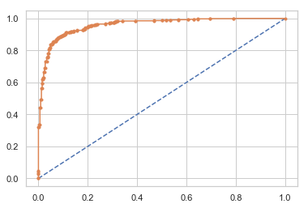

```python
# predict probabilities
probs = bgcl.predict_proba(X_train)
# keep probabilities for the positive outcome only
probs = probs[:, 1]
# calculate AUC
from sklearn.metrics import roc_auc_score
BGCL_train_auc = roc_auc_score(y_train, probs)
print('AUC: %.3f' % BGCL_train_auc)
# calculate roc curve
from sklearn.metrics import roc_curve
fpr, tpr, thresholds = roc_curve(y_train, probs)
plt.plot([0, 1], [0, 1], linestyle='--')
# plot the roc curve for the model
plt.plot(fpr, tpr, marker='.')
# show the plot
plt.show()
```

```python
nba_metrics=classification_report(y_test, y_predict_bgcl_test,output_dict=True)
dftr=pd.DataFrame(nba_metrics).transpose()
bgcl_test_f1=round(dftr.loc["1"][2],2)
bgcl_test_recall=round(dftr.loc["1"][1],2)
bgcl_test_precision=round(dftr.loc["1"][0],2)
bgcl_test_acc=round(dftr.loc["accuracy"][0],2)

print ('bgcl_test_precision ',bgcl_test_precision)
print ('bgcl_test_recall ',bgcl_test_recall)
print ('bgcl_test_f1 ',bgcl_test_f1)
print ('bgcl_test_acc ',bgcl_test_acc)
```

```
bgcl_test_precision  0.87
bgcl_test_recall  0.86
bgcl_test_f1  0.88
bgcl_test_acc  0.81
```

```
AUC: 0.882
```

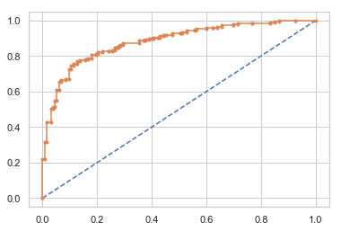

```python
# predict probabilities
probs = bgcl.predict_proba(X_test)
# keep probabilities for the positive outcome only
probs = probs[:, 1]
# calculate AUC
from sklearn.metrics import roc_auc_score
BGCL_test_auc = roc_auc_score(y_test, probs)
print('AUC: %.3f' % BGCL_test_auc)
# calculate roc curve
from sklearn.metrics import roc_curve
fpr, tpr, thresholds = roc_curve(y_test, probs)
plt.plot([0, 1], [0, 1], linestyle='--')
# plot the roc curve for the model
plt.plot(fpr, tpr, marker='.')
# show the plot
plt.show()
```

##### Boosting(Ada Bossting)

```python
from sklearn.ensemble import AdaBoostClassifier
abcl = AdaBoostClassifier(n_estimators=10, random_state=42)
abcl
```

```
AdaBoostClassifier(n_estimators=10, random_state=42)
```

```python
abcl = abcl.fit(X_train, y_train)
```

```python
y_predict_abcl_train = abcl.predict(X_train)
```

```python
abcl.score(X_train, y_train)
```

```
0.8434864104967198
```

```python
confusion_matrix(y_train, y_predict_abcl_train)
```

```
array([[232,  97],
       [ 70, 668]], dtype=int64)
```

```python
print(classification_report(y_train,y_predict_abcl_train),"\n")
```

```
              precision    recall  f1-score   support

           0       0.77      0.71      0.74       329
           1       0.87      0.91      0.89       738

    accuracy                           0.84      1067
   macro avg       0.82      0.81      0.81      1067
weighted avg       0.84      0.84      0.84      1067
```

```python
y_predict_abcl_test = abcl.predict(X_test)
```

```python
abcl.score(X_test, y_test)
```

```
0.8100436681222707
```

```python
confusion_matrix(y_test, y_predict_abcl_test)
```

```
array([[ 85,  48],
       [ 39, 286]], dtype=int64)
```

```python
print(classification_report(y_test,y_predict_abcl_test),"\n")
```

```
              precision    recall  f1-score   support

           0       0.69      0.64      0.66       133
           1       0.86      0.88      0.87       325

    accuracy                           0.81       458
   macro avg       0.77      0.76      0.76       458
weighted avg       0.81      0.81      0.81       458
```

```python
nba_metrics=classification_report(y_train, y_predict_abcl_train,output_dict=True)
dftr=pd.DataFrame(nba_metrics).transpose()
abcl_train_f1=round(dftr.loc["1"][2],2)
abcl_train_recall=round(dftr.loc["1"][1],2)
abcl_train_precision=round(dftr.loc["1"][0],2)
abcl_train_acc=round(dftr.loc["accuracy"][0],2)

print ('abcl_train_precision ',abcl_train_precision)
print ('abcl_train_recall ',abcl_train_recall)
print ('abcl_train_f1 ',abcl_train_f1)
print ('abcl_train_acc ',abcl_train_acc)
```

```
abcl_train_precision  0.89
abcl_train_recall  0.87
abcl_train_f1  0.91
abcl_train_acc  0.84
```

```
AUC: 0.901
```

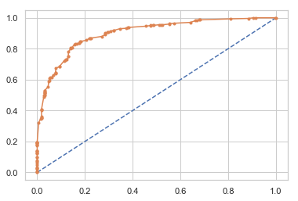

```python
# predict probabilities
probs = abcl.predict_proba(X_train)
# keep probabilities for the positive outcome only
probs = probs[:, 1]
# calculate AUC
from sklearn.metrics import roc_auc_score
ABCL_train_auc = roc_auc_score(y_train, probs)
print('AUC: %.3f' % ABCL_train_auc)
# calculate roc curve
from sklearn.metrics import roc_curve
fpr, tpr, thresholds = roc_curve(y_train, probs)
plt.plot([0, 1], [0, 1], linestyle='--')
# plot the roc curve for the model
plt.plot(fpr, tpr, marker='.')
# show the plot
plt.show()
```

```python
nba_metrics=classification_report(y_test, y_predict_abcl_test,output_dict=True)
dftr=pd.DataFrame(nba_metrics).transpose()
abcl_test_f1=round(dftr.loc["1"][2],2)
abcl_test_recall=round(dftr.loc["1"][1],2)
abcl_test_precision=round(dftr.loc["1"][0],2)
abcl_test_acc=round(dftr.loc["accuracy"][0],2)

print ('abcl_test_precision ',abcl_test_precision)
print ('abcl_test_recall ',abcl_test_recall)
print ('abcl_test_f1 ',abcl_test_f1)
print ('abcl_test_acc ',abcl_test_acc)
```

```
abcl_test_precision  0.87
abcl_test_recall  0.86
abcl_test_f1  0.88
abcl_test_acc  0.81
```

```
AUC: 0.871
```

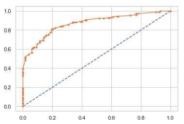

```python
# predict probabilities
probs = abcl.predict_proba(X_test)
# keep probabilities for the positive outcome only
probs = probs[:, 1]
# calculate AUC
from sklearn.metrics import roc_auc_score
ABCL_test_auc = roc_auc_score(y_test, probs)
print('AUC: %.3f' % ABCL_test_auc)
# calculate roc curve
from sklearn.metrics import roc_curve
fpr, tpr, thresholds = roc_curve(y_test, probs)
plt.plot([0, 1], [0, 1], linestyle='--')
# plot the roc curve for the model
plt.plot(fpr, tpr, marker='.')
# show the plot
plt.show()
```

```python
index=['Accuracy', 'AUC', 'Recall','Precision','F1 Score']
data3 = pd.DataFrame({'DTCL Train':[dtcl_train_acc,dtcl_train_auc,dtcl_train_recall,dtcl_train_precision,dtcl_train_f1],
        'DTCL Test':[dtcl_test_acc,DTCL_test_auc,dtcl_test_recall,dtcl_test_precision,dtcl_test_f1],
       'BGCL Train':[bgcl_train_acc,BGCL_train_auc,bgcl_train_recall,bgcl_train_precision,bgcl_train_f1],
        'BGCL Test':[bgcl_test_acc,BGCL_test_auc,bgcl_test_recall,bgcl_test_precision,bgcl_test_f1],
        'ABCL Train':[abcl_train_acc,ABCL_train_auc,abcl_train_recall,abcl_train_precision,abcl_train_f1],
        'ABCL Test':[abcl_test_acc,ABCL_test_auc,abcl_test_recall,abcl_test_precision,abcl_test_f1],},index=index)
round(data3,2)
```

|  | DTCL Train | DTCL Test | BGCL Train | BGCL Test | ABCL Train | ABCL Test |
| --- | --- | --- | --- | --- | --- | --- |
| Accuracy | 0.81 | 0.78 | 0.90 | 0.81 | 0.84 | 0.81 |
| AUC | 0.87 | 0.84 | 0.96 | 0.88 | 0.90 | 0.87 |
| Recall | 0.85 | 0.83 | 0.91 | 0.86 | 0.87 | 0.86 |
| Precision | 0.87 | 0.85 | 0.93 | 0.87 | 0.89 | 0.87 |
| F1 Score | 0.89 | 0.87 | 0.95 | 0.88 | 0.91 | 0.88 |

From the above comparison table, we can infer that Bagging classifier gives the best result for training dataset and testing dataset.

### 1.7 Performance Metrics: Check the performance of Predictions on Train and Test sets using Accuracy, Confusion Matrix, Plot ROC curve and get ROC_AUC score for each model. Final Model: Compare the models and write inference which model is best/optimized. (7 marks)

```python
pd.concat([data1, data2, data3], axis=1)
```

|  | LR Train | LR Test | LDA Train | LDA Test | NNH Train | NNH Test | NBA Train | NBA Test | DTCL Train | DTCL Test | BGCL Train | BGCL Test | ABCL Train | ABCL Test |
| --- | --- | --- | --- | --- | --- | --- | --- | --- | --- | --- | --- | --- | --- | --- |
| Accuracy | 0.840000 | 0.810000 | 0.840000 | 0.81000 | 1.000000 | 0.800000 | 0.840000 | 0.810000 | 0.810000 | 0.780000 | 0.900000 | 0.810000 | 0.840000 | 0.810000 |
| AUC | 0.894867 | 0.871764 | 0.894529 | 0.87306 | 0.999998 | 0.840648 | 0.891535 | 0.866767 | 0.865256 | 0.836576 | 0.959113 | 0.882244 | 0.901243 | 0.871267 |
| Recall | 0.870000 | 0.840000 | 0.870000 | 0.85000 | 1.000000 | 0.860000 | 0.880000 | 0.860000 | 0.850000 | 0.830000 | 0.910000 | 0.860000 | 0.870000 | 0.860000 |
| Precision | 0.890000 | 0.870000 | 0.890000 | 0.87000 | 1.000000 | 0.860000 | 0.880000 | 0.870000 | 0.870000 | 0.850000 | 0.930000 | 0.870000 | 0.890000 | 0.870000 |
| F1 Score | 0.910000 | 0.900000 | 0.910000 | 0.89000 | 1.000000 | 0.860000 | 0.890000 | 0.880000 | 0.890000 | 0.870000 | 0.950000 | 0.880000 | 0.910000 | 0.880000 |

The bagging classifier(using Random Forest classifier) gives the best result for both training and test data.

### 1.8 Based on these predictions, what are the insights?

$Blair Manifesto for Labour party $:

1. Working hours will be reduced for the labour.
2. Working benefits will be improved.
3. Medical benefits will be improved.

$Hague Manifesto for conservative party $:

1. Education will be made available for all.
2. Medical benefits will be improved.
3. Standard of living will be improved.
4. Accessibility of financial facilities will be improved.
5. Lending rates of bank will be reduced.
6. Interest on deposits will be improved.

### 2.) In this particular project, we are going to work on the inaugural corpora from the nltk in Python. We will be looking at the following speeches of the Presidents of the United States of America:

1.)President Franklin D. Roosevelt in 1941

2.)President John F. Kennedy in 1961

3.)President Richard Nixon in 1973

```python
import nltk
from nltk.tokenize import word_tokenize,sent_tokenize
from nltk.corpus import stopwords
nltk.download('punkt')
nltk.download('inaugural')
nltk.download('stopwords')
from nltk.corpus import inaugural
import string
inaugural.fileids
Roosevelt = inaugural.raw('1941-Roosevelt.txt')
Kennedy = inaugural.raw('1961-Kennedy.txt')
Nixon = inaugural.raw('1973-Nixon.txt')
```

### 2.1 Find the number of characters, words, and sentences for the mentioned documents.

```python
print("Number of Character in 1941-Roosevelt text file ",len(Roosevelt))
print("Number of words in 1941-Roosevelt text file ",len(word_tokenize(Roosevelt)))
print("Number of sentence in 1941-Roosevelt text file ",len(sent_tokenize(Roosevelt)))
```

```
Number of Character in 1941-Roosevelt text file  7571
Number of words in 1941-Roosevelt text file  1526
Number of sentence in 1941-Roosevelt text file  68
```

```python
print("Number of Character in 1961-Kennedy text file ",len(Kennedy))
print("Number of words in 1961-Kennedy text file ",len(word_tokenize(Kennedy)))
print("Number of sentence in 1961-Kennedy text file ",len(sent_tokenize(Kennedy)))
```

```
Number of Character in 1961-Kennedy text file  7618
Number of words in 1961-Kennedy text file  1543
Number of sentence in 1961-Kennedy text file  52
```

```python
print("Number of Character in 1973-Nixon text file ",len(Nixon))
print("Number of words in 1973-Nixon text file ",len(word_tokenize(Nixon)))
print("Number of sentence 1973-Nixon text file ",len(sent_tokenize(Nixon)))
```

```
Number of Character in 1973-Nixon text file  9991
Number of words in 1973-Nixon text file  2006
Number of sentence 1973-Nixon text file  68
```

### 2.2 Remove all the stopwords from all three speeches.

```python
stopwords_wordcloud_Roosevelt = nltk.corpus.stopwords.words('english') +list(string.punctuation)
all_words_Roosevelt = (w.lower() for w in inaugural.words('1941-Roosevelt.txt'))
all_words_clean_Roosevelt = [word for word in all_words_Roosevelt if word not in stopwords_wordcloud_Roosevelt]

stop_words = set(stopwords.words('english')+list(string.punctuation))

word_tokens = word_tokenize(Roosevelt)

filtered_sentence_Roosevelt = [w for w in word_tokens if not w.lower() in stop_words]

filtered_sentence_Roosevelt = []

for w in word_tokens:
    if w not in stop_words:
        filtered_sentence_Roosevelt.append(w)
filtered_sentence_Roosevelt
```

```
['On',
 'national',
 'day',
 'inauguration',
 'since',
 '1789',
 'people',
 'renewed',
 'sense',
 'dedication',
 'United',
 'States',
 'In',
 'Washington',
 "'s",
 'day',
 'task',
 'people',
 'create',
 'weld',
 'together',
 'nation',
 'In',
 'Lincoln',
 "'s",
 'day',
 'task',
 'people',
 'preserve',
 'Nation',
 'disruption',
 'within',
 'In',
 'day',
 'task',
 'people',
 'save',
 'Nation',
 'institutions',
 'disruption',
```

[output cut: 665 more lines]

```
 'faith',
 'America',
 'We',
 'retreat',
 'We',
 'content',
 'stand',
 'still',
 'As',
 'Americans',
 'go',
 'forward',
 'service',
 'country',
 'God']
```

```python
print("Number of words count before removing stopwords in 1941-Roosevelt text file ",len(word_tokenize(Roosevelt)))
print("Number of words count after removing stopwords in 1941-Roosevelt text file ",len((filtered_sentence_Roosevelt)))
```

```
Number of words count before removing stopwords in 1941-Roosevelt text file  1526
Number of words count after removing stopwords in 1941-Roosevelt text file  720
```

```python
stopwords_wordcloud_Kennedy = nltk.corpus.stopwords.words('english') +list(string.punctuation)
all_words_Kennedy = (w.lower() for w in inaugural.words('1961-Kennedy.txt'))
all_words_clean_Kennedy = [word for word in all_words_Kennedy if word not in stopwords_wordcloud_Kennedy]

stop_words = set(stopwords.words('english')+list(string.punctuation))

word_tokens = word_tokenize(Kennedy)

filtered_sentence_Kennedy = [w for w in word_tokens if not w.lower() in stop_words]

filtered_sentence_Kennedy = []

for w in word_tokens:
    if w not in stop_words:
        filtered_sentence_Kennedy.append(w)
filtered_sentence_Kennedy
```

```
['Vice',
 'President',
 'Johnson',
 'Mr.',
 'Speaker',
 'Mr.',
 'Chief',
 'Justice',
 'President',
 'Eisenhower',
 'Vice',
 'President',
 'Nixon',
 'President',
 'Truman',
 'reverend',
 'clergy',
 'fellow',
 'citizens',
 'observe',
 'today',
 'victory',
 'party',
 'celebration',
 'freedom',
 '--',
 'symbolizing',
 'end',
 'well',
 'beginning',
 '--',
 'signifying',
 'renewal',
 'well',
 'change',
 'For',
 'I',
 'sworn',
 'I',
 'Almighty',
```

[output cut: 708 more lines]

```
 'lead',
 'land',
 'love',
 'asking',
 'His',
 'blessing',
 'His',
 'help',
 'knowing',
 'earth',
 'God',
 "'s",
 'work',
 'must',
 'truly']
```

```python
print("Number of words count before removing stopwords in 1961-Kennedy text file ",len(word_tokenize(Kennedy)))
print("Number of words count after removing stopwords in 1961-Kennedy text file ",len((filtered_sentence_Kennedy)))
```

```
Number of words count before removing stopwords in 1961-Kennedy text file  1543
Number of words count after removing stopwords in 1961-Kennedy text file  763
```

```python
stopwords_wordcloud_Nixon = nltk.corpus.stopwords.words('english') +list(string.punctuation)
all_words_Nixon = (w.lower() for w in inaugural.words('1973-Nixon.txt'))
all_words_clean_Nixon = [word for word in all_words_Nixon if word not in stopwords_wordcloud_Nixon]


stop_words = set(stopwords.words('english')+list(string.punctuation))

word_tokens = word_tokenize(Nixon)

filtered_sentence_Nixon = [w for w in word_tokens if not w.lower() in stop_words]

filtered_sentence_Nixon = []

for w in word_tokens:
    if w not in stop_words:
        filtered_sentence_Nixon.append(w)
filtered_sentence_Nixon
```

```
['Mr.',
 'Vice',
 'President',
 'Mr.',
 'Speaker',
 'Mr.',
 'Chief',
 'Justice',
 'Senator',
 'Cook',
 'Mrs.',
 'Eisenhower',
 'fellow',
 'citizens',
 'great',
 'good',
 'country',
 'share',
 'together',
 'When',
 'met',
 'four',
 'years',
 'ago',
 'America',
 'bleak',
 'spirit',
 'depressed',
 'prospect',
 'seemingly',
 'endless',
 'war',
 'abroad',
 'destructive',
 'conflict',
 'home',
 'As',
 'meet',
 'today',
 'stand',
```

[output cut: 869 more lines]

```
 'hope',
 'strong',
 'faith',
 'one',
 'another',
 'sustained',
 'faith',
 'God',
 'created',
 'us',
 'striving',
 'always',
 'serve',
 'His',
 'purpose']
```

```python
print("Number of words count before removing stopwords in 1973-Nixon text file ",len(word_tokenize(Nixon)))
print("Number of words count after removing stopwords in 1973-Nixon text file ",len((filtered_sentence_Nixon)))
```

```
Number of words count before removing stopwords in 1973-Nixon text file  2006
Number of words count after removing stopwords in 1973-Nixon text file  924
```

### 2.3 Which word occurs the most number of times in his inaugural address for each president? Mention the top three words. (after removing the stopwords)

```python
fdist_Roosevelt = nltk.FreqDist(filtered_sentence_Roosevelt)
fdist_Roosevelt.most_common(4)
```

```
[('--', 25), ('It', 13), ('The', 10), ('know', 10)]
```

```python
fdist_Roosevelt.most_common()
```

```
[('--', 25),
 ('It', 13),
 ('The', 10),
 ('know', 10),
 ('We', 10),
 ('spirit', 9),
 ('life', 9),
 ('us', 8),
 ('democracy', 8),
 ('people', 7),
 ('Nation', 7),
 ('America', 7),
 ('years', 6),
 ('freedom', 6),
 ('In', 5),
 ("'s", 5),
 ('nation', 5),
 ('human', 5),
 ('men', 5),
 ('body', 5),
 ('mind', 5),
 ('speaks', 5),
 ('day', 4),
 ('States', 4),
 ('For', 4),
 ('must', 4),
 ('something', 4),
 ('faith', 4),
 ('United', 3),
 ('task', 3),
 ('within', 3),
 ('history', 3),
 ('nations', 3),
 ('live', 3),
 ('future', 3),
 ('But', 3),
 ('new', 3),
 ('free', 3),
 ('alone', 3),
 ('still', 3),
```

[output cut: 396 more lines]

```
 ('never', 1),
 ('encountered', 1),
 ('strong', 1),
 ('purpose', 1),
 ('protect', 1),
 ('perpetuate', 1),
 ('integrity', 1),
 ('muster', 1),
 ('retreat', 1),
 ('content', 1),
 ('stand', 1),
 ('As', 1),
 ('service', 1),
 ('country', 1),
 ('God', 1)]
```

```python
fdist_Kennedy = nltk.FreqDist(filtered_sentence_Kennedy)
fdist_Kennedy.most_common(4)
```

```
[('--', 25), ('us', 12), ('world', 8), ('Let', 8)]
```

```python
fdist_Kennedy.most_common()
```

```
[('--', 25),
 ('us', 12),
 ('world', 8),
 ('Let', 8),
 ('let', 8),
 ('sides', 8),
 ('new', 7),
 ('pledge', 7),
 ('citizens', 5),
 ('I', 5),
 ('power', 5),
 ('shall', 5),
 ('To', 5),
 ('free', 5),
 ('But', 5),
 ('ask', 5),
 ('President', 4),
 ('fellow', 4),
 ('freedom', 4),
 ('man', 4),
 ('And', 4),
 ('first', 4),
 ('Americans', 4),
 ('war', 4),
 ('peace', 4),
 ('always', 4),
 ('hope', 4),
 ('help', 4),
 ('nations', 4),
 ('arms', 4),
 ('country', 4),
 ('call', 4),
 ('today', 3),
 ('well', 3),
 ('For', 3),
 ('God', 3),
 ('The', 3),
 ('human', 3),
 ('poverty', 3),
 ('life', 3),
```

[output cut: 427 more lines]

```
 ('strength', 1),
 ('sacrifice', 1),
 ('With', 1),
 ('conscience', 1),
 ('sure', 1),
 ('reward', 1),
 ('judge', 1),
 ('lead', 1),
 ('land', 1),
 ('love', 1),
 ('asking', 1),
 ('blessing', 1),
 ('knowing', 1),
 ('work', 1),
 ('must', 1)]
```

```python
fdist_Nixon = nltk.FreqDist(filtered_sentence_Nixon)
fdist_Nixon.most_common(3)
```

```
[('us', 26), ('America', 21), ('peace', 19)]
```

```python
fdist_Nixon.most_common()
```

```
[('us', 26),
 ('America', 21),
 ('peace', 19),
 ('world', 17),
 ('--', 17),
 ('new', 15),
 ("'s", 14),
 ('Let', 13),
 ('I', 12),
 ('responsibility', 11),
 ('great', 9),
 ('home', 9),
 ('nation', 9),
 ('let', 9),
 ('We', 9),
 ('years', 7),
 ('shall', 7),
 ('policies', 7),
 ('role', 7),
 ('make', 7),
 ('every', 7),
 ('government', 7),
 ('history', 7),
 ('better', 7),
 ('together', 6),
 ('time', 6),
 ('right', 6),
 ('people', 6),
 ('help', 6),
 ('four', 5),
 ('abroad', 5),
 ('era', 5),
 ('responsibilities', 5),
 ('progress', 5),
 ('come', 5),
 ('respect', 5),
 ('others', 5),
 ('act', 5),
 ('one', 5),
 ('today', 4),
```

[output cut: 396 more lines]

```
 ('challenge', 1),
 ('next', 1),
 ('birthday', 1),
 ('young', 1),
 ('began', 1),
 ('bright', 1),
 ('beacon', 1),
 ('go', 1),
 ('sustained', 1),
 ('created', 1),
 ('striving', 1),
 ('always', 1),
 ('serve', 1),
 ('His', 1),
 ('purpose', 1)]
```

### 2.4 Plot the word cloud of each of the speeches of the variable. (after removing the stopwords) – 3 Marks [ refer to the End-to-End Case Study done in the Mentored Learning Session ]

```python
from wordcloud import WordCloud,STOPWORDS
```

```python
df_Roosevelt = all_words_clean_Roosevelt
words = ' '.join(df_Roosevelt)
```

```python
cleaned_word_Roosevelt = " ".join([word for word in words.split()
                            if 'http' not in word
                                and not word.startswith('@')
                                and word != 'RT'
                            ])
```

```python
wordcloud = WordCloud(stopwords=stopwords_wordcloud_Roosevelt,
                      width=3000,
                      height=2500
                     ).generate(cleaned_word_Roosevelt)
```

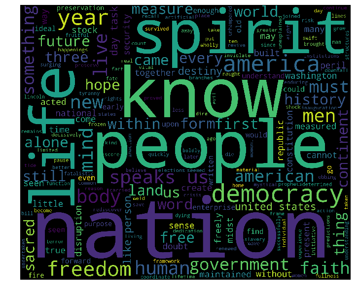

```python
plt.figure(figsize=(12, 12))
plt.imshow(wordcloud)
plt.axis('off')
plt.show()
```

```python
df_Kennedy = all_words_clean_Kennedy
words = ' '.join(df_Kennedy)
```

```python
cleaned_word_Kennedy = " ".join([word for word in words.split()
                            if 'http' not in word
                                and not word.startswith('@')
                                and word != 'RT'
                            ])
```

```python
wordcloud_Kennedy = WordCloud(stopwords=stopwords_wordcloud_Kennedy,
                      width=3000,
                      height=2500
                     ).generate(cleaned_word_Kennedy)
```

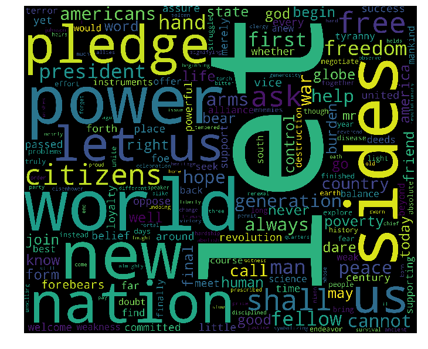

```python
plt.figure(figsize=(12, 12))
plt.imshow(wordcloud_Kennedy)
plt.axis('off')
plt.show()
```

```python
df_Nixon = all_words_clean_Nixon
words = ' '.join(df_Nixon)
```

```python
cleaned_word_Nixon = " ".join([word for word in words.split()
                            if 'http' not in word
                                and not word.startswith('@')
                                and word != 'RT'
                            ])
```

```python
wordcloud_Nixon = WordCloud(stopwords=stopwords_wordcloud_Nixon,
                      width=3000,
                      height=2500
                     ).generate(cleaned_word_Nixon)
```

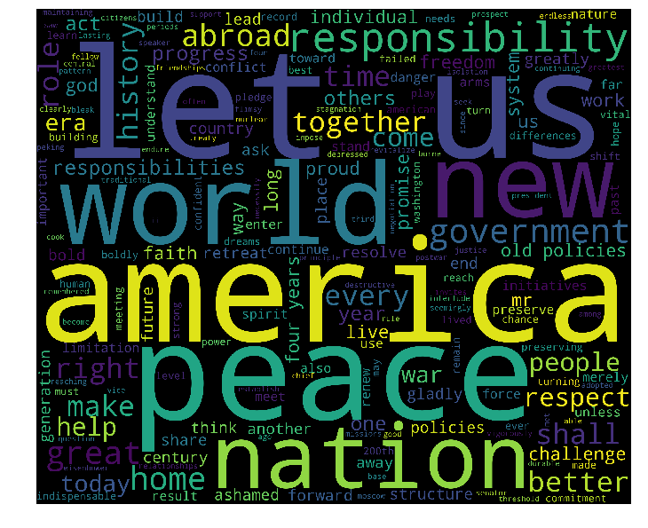

```python
plt.figure(figsize=(12, 12))
plt.imshow(wordcloud_Nixon)
plt.axis('off')
plt.show()
```